# TLIO: Tight Learned Inertial Odometry

- Paper: `arXiv:2007.01867v3` / IEEE Robotics and Automation Letters, 2020
- Authors: Wenxin Liu, David Caruso, Eddy Ilg, Jing Dong, Anastasios I. Mourikis, Kostas Daniilidis, Vijay Kumar, Jakob Engel
- Presentation Author: Javier Penuela

## Introduction to Pedestrian Dead Reckoning

- Pedestrian dead reckoning (PDR) estimates motion from inertial sensors alone.
- Traditional methods rely on step detection, stride models, and heading estimation.
- Challenges: sensor bias, noise, drift, arbitrary device orientation, and diverse human motion.
- This paper proposes an IMU-only system that avoids step counting by learning short-term displacement priors using a ResNet and physical process modeling.

## Dataset: Collection

- Collected with a custom rig: Bosch BMI055 IMU mounted on a headset rigidly attached to cameras.
- More than 400 sequences, totaling 60 hours of pedestrian data.
- Activities include walking, standing, kitchen tasks, playing pool, stairs, outdoor uneven terrain, and more.
- Data captured with multiple physical devices (visual data for ground true + IMU data) and over 5 people to cover varied motion patterns and IMU biases.
- Limitations: data excludes looking up or down positions, data does not reflect phone conditions, but smart glasses conditions.

## Dataset: Description

- Ground truth from a state-of-the-art visual-inertial filter at 1000 Hz.
- Dataset split randomly into 80% training, 10% validation, 10% test. No difference between validation and test datasets is disclosed
- The dataset contains pedestrian trajectories with 3 to 7 minutes of activity per sequence.
- Benchmark comparison uses 3D-RoNIN as a reference baseline. Yet, it ignores RoNIN dataset (100 subjects and 42.7h of data, phone, different possitions)

## Dataset: Preprocessing

- Training uses overlapping sliding windows of IMU data.
- Each window contains N IMU samples; final choice is `N = 200` for 200 Hz data.
- Data augmentation:
  - random horizontal rotations for yaw invariance (following RoNIN)
  - random sensor bias perturbations
  - random gravity direction perturbations
- Goal: make the network robust to initialization error, bias, and gravity misalignment.

## Dataset: Gravity-Aligned Frame

- IMU samples are rotated to a local gravity-aligned frame built from the orientation at the beginning of each window.
- Gravity-aligned frame ensures gravity points downward and decouples global yaw from local displacement.
- The network input is therefore invariant to arbitrary heading of the headset.

Method:

Compute a reference array `ig_w: np.array([0, 0, 1.0])` representing gravity pointing "up" in the Z-axis of the world frame. then they compute the rotation matrix $R$ such that $R a = b$:

- Normalization: It normalizes both the input vector $a$ (the accelerometer reading) and the target vector $b$ (the gravity vector).
- Rotation Axis ($\omega$): It finds the axis of rotation by taking the cross product of the two vectors: $$\omega = \hat{a} \times \hat{b}$$ This vector $\omega$ is perpendicular to the plane formed by $a$ and $b$.
- Rodrigues' Rotation Formula: $$R = I + [\omega]_\times + \frac{1}{1 + \hat{a} \cdot \hat{b}} ([\omega]_\times)^2$$ $[\omega]_\times$: The skew-symmetric matrix of $\omega$ (computed by the hat(v) helper function -> `np.array([[0, -v[2], v[1]], [v[2], 0, -v[0]], [-v[1], v[0], 0]])`.

## System Design Overview

- Two main components:
  1. Neural network: regresses 3D displacement and uncertainty from IMU segments.
  2. Extended Kalman Filter (EKF): tightly fuses neural displacement measurements with IMU kinematics.
- The network learns a statistical motion prior from data, while the EKF performs model-based propagation.
- IMU data is used twice: directly for state propagation and indirectly as network measurement input. (Data argumentation prevents measurement error propagation to the model)

## Neural Network Description

- Architecture: 1D ResNet18 variant.
- Input: `N x 6` IMU window, where each sample contains accelerometer and gyroscope measurements in gravity-aligned frame.
- Output (one independent FC block (3 layers) per output):
  - $\hat d \in \mathbb{R}^3$: predicted 3D displacement over the window
  - $\hat u \in \mathbb{R}^3$: uncertainty parameters for the displacement covariance
- The network output is treated as a measurement of relative displacement with uncertainty.

## Loss Functions

- Mean Squared Error (MSE) loss:

$$ L_{\text{MSE}} = \frac{1}{n} \sum_{i=1}^n \| d_i - \hat d_i \|^2 $$

- Maximum Likelihood loss for regressed Gaussian displacement:

$$ L_{\text{ML}} = \frac{1}{n} \sum_{i=1}^n \left( \frac{1}{2} \log \det \Sigma_i + \frac{1}{2} (d_i - \hat d_i)^T \Sigma_i^{-1} (d_i - \hat d_i) \right) + \text{const} $$

- Covariance parametrization by log-standard deviation:

$$ \Sigma_i = \operatorname{diag}\left(e^{2 u_{x,i}}, e^{2 u_{y,i}}, e^{2 u_{z,i}}\right) $$

- Best performing training strategy: first train with MSE until stable, then switch to likelihood loss.

## Stochastic Cloning

- The EKF state includes the current state and a sliding window of past cloned poses.
- A cloned pose is appended whenever a new network measurement is available.
- This allows the filter to use relative displacement measurements between pairs of past states. (i.e. to interpolate `m` piece-wise linear aproximations of the non-linear function between samples `n+k` to `n+k+1` )
- Full state:

$$ \mathbf{X} = (\xi_1, \dots, \xi_m, \mathbf{s}) $$

where $\xi_i = ({}^w_i\mathbf{R}_i, {}^w\mathbf{p}_i)$ represents past orientations and positions, and $\mathbf{s}=({}^w_i\mathbf{R}_i, {}^w\mathbf{v}, {}^w\mathbf{p}, \mathbf{b}_g), \mathbf{b}_a$ current position and orientation with dimensions:

$$ \text{dim}(X) = 6m + 15 $$

where `m` is the number of past cloned states.

- Example: with 20 Hz updates and a 1 s window, up to 21 states are maintained.

For the error propagation we apply the error-based filltering method:

Cloned state error: $$\tilde{\xi}_i = (\tilde{\theta}_i, \tilde{\mathbf{p}}_i)$$

Current state error: $$\tilde{\mathbf{s}} = (\tilde{\theta}, \tilde{\mathbf{v}}, \tilde{\mathbf{p}}, \tilde{\mathbf{b}}_g, \tilde{\mathbf{b}}_a)$$

where the rotation error on the $SO(3)$: $\tilde{\theta} = \log_{SO3}(\mathbf{R} \hat{\mathbf{R}}^{-1})$.

## EKF Architecture and Equations

### Propagation model

Strapdown inertial kinematics with IMU bias and gravity:

$$ R_{k+1} = R_k \exp_{\mathrm{SO(3)}}\left((\omega_k - b_{g,k}) \Delta t\right) $$ $$ v_{k+1} = v_k + g \Delta t + R_k (a_k - b_{a,k}) \Delta t $$ $$ p_{k+1} = p_k + v_k \Delta t + \frac{1}{2} \left(g + R_k (a_k - b_{a,k}) \right) \Delta t^2 $$ $$ b_{g,k+1} = b_{g,k} + n_{g,k}, \qquad b_{a,k+1} = b_{a,k} + n_{a,k} $$

### Linearized propagation

$$ \tilde s_{k+1} = A_k \tilde s_k + B_k n_k $$

Standard Propagation:

$$ P_{k+1} = A_k P_k A_k^T + B_k W B_k^T $$

$$ A_k = \begin{bmatrix} I_{6m} & 0 \\ 0 & A_{s,k} \end{bmatrix}, \quad B_k = \begin{bmatrix} 0 \\ B_{s,k} \end{bmatrix} $$

Propagation with Stochastic Cloning:

$$ \bar{P}_{k+1} = \bar{A}_k P_k \bar{A}k^T + \bar{B}k \bar{W} \bar{B}k^T $$ $$ \bar{A}k = \begin{bmatrix} I_{6m} & 0 \\ 0 & A_{\xi,k} \\ 0 & A_{s,k} \end{bmatrix}, \quad \bar{B}k = \begin{bmatrix} 0 \\ B_{\xi,k} \\ B_{s,k} \end{bmatrix} $$

### Measurement model in gravity-aligned frame

The network predicts a local displacement measurement:

$$ h(X) = R_\gamma^T (p_j^w - p_i^w) = \hat d_{ij} + \eta_{d_{ij}} $$

where $\eta_{d_{ij}}$ is normally distributed noise, with a zero mean and variance $\hat \Sigma_{ij}$ from the network.

$$\mathbf{H}_{\tilde{\theta}_i} = \frac{\partial h(\mathbf{X})}{\partial \tilde{\theta}_i} = \lfloor \hat{\mathbf{R}}_\gamma^T [{}^w\hat{\mathbf{p}}_j - {}^w\hat{\mathbf{p}}i]_\times \mathbf{H}_z$$

$$\mathbf{H}_{\tilde{\mathbf{\delta p}}_i} = \frac{\partial h(\mathbf{X})}{\partial \delta \tilde{\mathbf{p}}_i} = -\hat{\mathbf{R}}_\gamma^T$$

$$\mathbf{H}_{\tilde{\mathbf{\delta p}}_j} = \frac{\partial h(\mathbf{X})}{\partial \delta \tilde{\mathbf{p}}_j} = \hat{\mathbf{R}}_\gamma^T$$

where $$\mathbf{H}_z = \begin{bmatrix} 0 & 0 & 0 \\ 0 & 0 & 0 \\ \cos \gamma \tan \beta & \sin \gamma \tan \beta & 1 \end{bmatrix}$$

### Kalman update

$$ K = P H^T (H P H^T + \hat \Sigma_{ij})^{-1} $$ $$ X \leftarrow X \oplus K (h(X) - \hat d_{ij}) $$ $$ P \leftarrow (I - K H) P (I - K H)^T + K \hat \Sigma_{ij} K^T $$

- Measurement Jacobian `H` has nonzero blocks only for the cloned poses `i` and `j`.
- A $\chi^2$ gating test rejects updates with normalized innovation beyond the 99%-tile.

## Metrics

- Absolute Translation Error (ATE):

$$ \text{ATE} = \sqrt{\frac{1}{n} \sum_{k=1}^n \| p_k^w - \hat p_k^w \|^2} $$

- Relative Translation Error (RTE(t)): $$ \text{RTE}_{\Delta t} = \sqrt{\frac{1}{n} \sum{i=1}^n \left| ({}^w\mathbf{p}_{i+\Delta t} - {}^w\mathbf{p}_i) - \mathbf{R}_\gamma \hat{\mathbf{R}}_\gamma^T ({}^w\hat{\mathbf{p}}_{i+\Delta t} - {}^w\hat{\mathbf{p}}_i) \right|^2} $$
- Drift Rate (DR): $$ \text{DR}(\%) = \frac{| {}^w\mathbf{p}_n - {}^w\hat{\mathbf{p}}_n |}{\text{trajectory-length}} \times 100 $$
- Absolute Yaw Error (AYE): $$ \text{AYE} = \sqrt{\frac{1}{n} \sum_{i=1}^n | \psi_i - \hat{\psi}_i |^2} $$
- Relative Yaw Error (RYE(t)): $$ \text{RYE}_{\Delta t} = \sqrt{\frac{1}{n} \sum{i=1}^n | (\psi_{i+t} - \psi_i) - (\hat{\psi}_{i+t} - \hat{\psi}_i) |^2} $$
- Yaw Drift Rate (Yaw-DR): $$ \text{Yaw-DR} = \frac{| \psi_n - \hat{\psi}_n |}{\text{sequence-duration}} $$
- The paper reports cumulative distribution functions of these metrics over the test set.

# Author's presented results

1. ResNet outperforms the Resnet seq2seq and TCN
2. TLIO outperforms allways 3d RoNIN

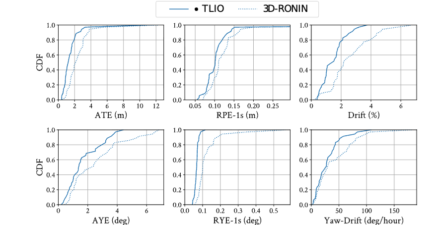

# Author's presented results

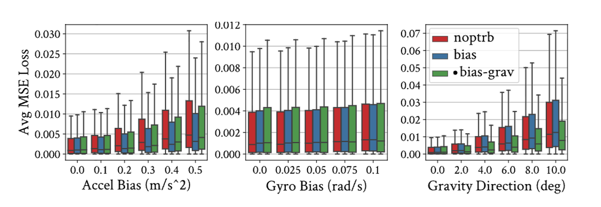

# Author's presented results

4. The NN almost always outputs values in the $3\sigma$ range. Still an outlyer filter is implemented.

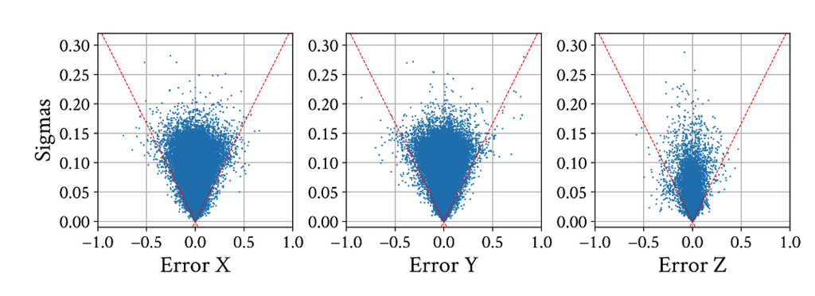

# Author's presented results

5. The filter is sensitive to sampling rate and prediction window size

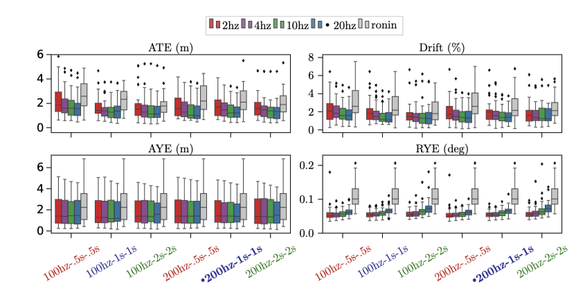

# Analysis process

The process included

- Reading the article and related sources
- Adapting the code to run in a Mac M4 chip (some libraries and dependencies had to be adapted)
- Limiting logging to fit the training process in 16GB of VRAM
- Several small memory usage tweeks
- Creation of a Dockerfile (needs testing on NVidia GPUs)
- Several small adaptations for the code to run as intented
- Generating a description file of the directory
- updating the original Readme.md file to fit the changes made
- Training the models (50 epoch)
- Running the benchmarks
- Adapting a benchmark for inference time
- Doing this presentation

## Experimental Results

- The code with the provided environment works well, with the exception of the 3D visualisation module (not compatible with ARM processors)
- The model selection (among the 3 proposed options by the authors) is correct.
- Validation is lower than training in some models, suggesting that the validation set is easier for the model than the training set. Given the small size of the data set, this is likely.

[interactive chart not shown]

## Experimental Results -Resnet

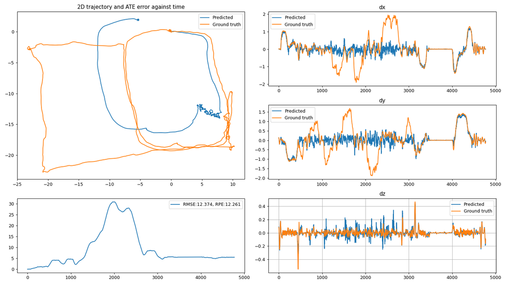

## Experimental Results - ResNet seq2seq

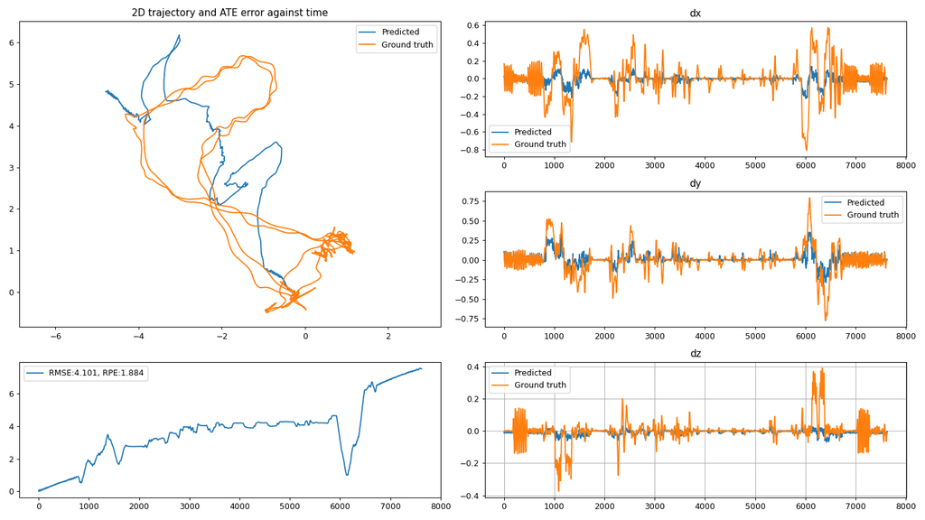

## Experimental Results -TCN

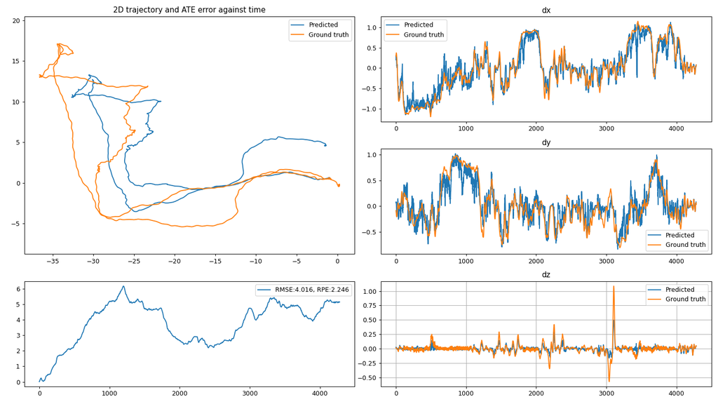

## Experimental Results

### NN benchmarking

- The authors provided a test for the NNs in isolation (use ground true initial position, so the NNs is evaluated in absolute terms).
- We used the provided test by the authors to obtain ATE, RTE and drift.
- We made the script test_nn_inf_time to benchmark inference time (full seq, avg single token time, num of predicted tokens) based on the test.py function

```
Loading ../batch_test_outputs/models-resnet/metrics.json
Loading ../batch_test_outputs/models-resnet_seq/metrics.json
Loading ../batch_test_outputs/models-tcn/metrics.json

Models found:
['models-resnet' 'models-resnet_seq' 'models-tcn']

Numeric columns:
['rmse', 'ate', 'rmhe', 'drift_pos (m/m)', 'drift_yaw (deg/s)', 'rpe', 'rpe_z', 'rpe_yaw', 'mse_loss_x', 'mse_loss_y', 'mse_loss_z', 'mse_loss_avg', 'likelihood_loss_x', 'likelihood_loss_y', 'likelihood_loss_z', 'likelihood_loss_avg', 'sample_id']
```

## Experimental Results

### NN benchmarking

[interactive chart not shown]

## Experimental Results

### NN benchmarking

[interactive chart not shown]

## Experimental Results

### NN benchmarking

[interactive chart not shown]

## Experimental Results

### NN benchmarking

[interactive chart not shown]

## Experimental Results

### NN benchmarking

[interactive chart not shown]

## Experimental Results

### NN benchmarking

[interactive chart not shown]

## Experimental Results

### NN benchmarking

[interactive chart not shown]

## Filter Benchmark -ATE

[interactive chart not shown]

## Filter Benchmark -Drift

[interactive chart not shown]

## Filter Benchmark -RTE

[interactive chart not shown]

## Filter Benchmark -Angular drift

Possible bug:RoNIN uses EFK yew calculations.

[interactive chart not shown]

## Filter Benchmark -AYE

[interactive chart not shown]

## Filter Benchmark -RYE

[interactive chart not shown]

## Filter Benchmark - Num updates

[interactive chart not shown]

## Filter Benchmark -Sequence duration (calculation time)

- includes logs, and other add-ons

[interactive chart not shown]

## Filter Benchmark -Update time

[interactive chart not shown]

## System Performance

- TLIO consistently outperforms 3D-RoNIN on all reported metrics.
- We could not corroborate that the EKF also reduces yaw drift compared to a decoupled attitude filter.
- Key advantages:
  - the physics+ statistical modelling approach yeils better results than simply replacing the estimation stage with an NN
  - filter robustness to outliers.
- the system may be light enough to run online.

## Presenter Comments

- There is no clarification on what makes validation and test datasets different
- The authors talk about the world frame, but their code (correctly) does not use the visual data to align the dataset with a true world frame, only to the gravity-aligned frame.
- Initialisation assumes that the IMU is vertical, --> in real life, that is a poor calibration for the phones.
- In the update part of the filter, it uses Euler angles --> this architecture can present Gimbal lock
- The NN processing time is much faster than 1/200 (sampling rate)--> the NN can run online, same for the whole filter.
- The time benchmark is realised in an ARM architecture --> best approximation to phones.
- the authors claim no hardcoded values, that is an overstatement
- The code is very well done, yet it presents some bugs, likely not visible to the authors due to the use of a single system

# Add-ons 18/05/2026

- distance estimation relative error to the ground true distance (%)

[interactive chart not shown]

# Add-ons 18/05/2026

- NN uncertainty box plot (includes mean) -x

[interactive chart not shown]

# Add-ons 18/05/2026

- NN uncertainty box plot (includes mean) -y

[interactive chart not shown]

# Add-ons 18/05/2026

- NN uncertainty box plot (includes mean) -z

[interactive chart not shown]

# Add-ons 18/05/2026

- NN absolute error box plot (includes mean) -x

[interactive chart not shown]

# Add-ons 18/05/2026

- NN absolute error box plot (includes mean) -y

[interactive chart not shown]

# Add-ons 18/05/2026

- NN absolute error box plot (includes mean) -z

[interactive chart not shown]

# Add-ons 18/05/2026

- NN mean error box plot (includes mean) -absolute distance

[interactive chart not shown]